# Data Camp Insights

```r
summary(djx_extremes)
```

```
##      Index                 ^DJI
##  Min.   :1987-04-03   Min.   :0.02650
##  1st Qu.:1998-09-06   1st Qu.:0.02928
##  Median :2002-10-16   Median :0.03262
##  Mean   :2002-05-05   Mean   :0.03781
##  3rd Qu.:2008-12-05   3rd Qu.:0.04113
##  Max.   :2015-08-26   Max.   :0.10508
```

```r
exp_quantiles <- c(0.005013, 0.015114, 0.025318, 0.035627, 0.046044, 0.05657, 0.067209, 0.077962, 0.088831, 0.09982, 0.110932, 0.122168, 0.133531, 0.145026, 0.156654, 0.168419, 0.180324, 0.192372, 0.204567, 0.216913, 0.229413, 0.242072, 0.254892, 0.267879, 0.281038, 0.294371, 0.307885, 0.321584, 0.335473, 0.349557, 0.363843, 0.378336, 0.393043, 0.407968, 0.42312, 0.438505, 0.45413, 0.470004, 0.486133, 0.502527, 0.519194, 0.536143, 0.553385, 0.57093, 0.588787, 0.606969, 0.625489, 0.644357, 0.663588, 0.683197, 0.703198, 0.723606, 0.74444, 0.765718, 0.787458, 0.809681, 0.832409, 0.855666, 0.879477, 0.903868, 0.92887, 0.954512, 0.980829, 1.007858, 1.035637, 1.064211, 1.093625, 1.12393, 1.155183, 1.187444, 1.22078, 1.255266, 1.290984, 1.328025, 1.366492, 1.406497, 1.44817, 1.491655, 1.537117, 1.584745, 1.634756, 1.687399, 1.742969, 1.80181, 1.86433, 1.931022, 2.002481, 2.079442, 2.162823, 2.253795, 2.353878, 2.465104, 2.590267, 2.733368, 2.900422, 3.101093, 3.352407, 3.688879, 4.199705, 5.298317)
iid_extremes <- xts(c(2.485179, 2.335036, 2.348495, 2.609534, 2.571431, 2.505418, 3.436557, 2.306443, 2.406384, 2.249789, 2.699147, 2.384733, 2.462003, 2.825771, 2.658806, 2.696008, 2.484846, 2.253926, 2.390248, 2.753181, 3.026417, 2.305134, 2.365227, 2.499355, 2.844757, 2.290955, 3.048307, 2.906714, 2.536778, 2.574244, 2.740777, 2.259236, 2.247154, 2.338442, 2.597085, 2.435009, 2.905871, 2.211387, 2.807309, 2.76335, 2.505434, 2.512933, 2.655662, 2.362114, 2.300621, 2.635403, 2.554976, 2.255644, 2.397592, 2.214528, 2.391973, 2.72426, 2.926669, 2.213251, 2.576326, 2.249265, 2.402427, 2.678113, 2.243226, 2.513481, 2.961663, 2.597378, 2.498836, 2.983134, 2.234179, 2.769461, 2.288106, 2.465069, 2.236144, 2.732343, 2.610239, 2.432895, 2.319882, 2.215825, 2.606343, 3.282729, 2.437939, 3.132531, 2.231877, 2.391024, 2.441499, 2.389186, 2.319438, 2.926213, 2.457484, 3.396832, 2.288507, 2.240025, 2.696893, 2.541371, 2.410939, 2.51565, 2.660812, 2.378425, 2.274061, 2.544918, 2.236294, 2.569099, 3.256515, 2.428861), order.by=as.Date(c(5569, 5626, 5702, 6047, 6052, 6216, 6405, 6532, 6570, 6641, 6734, 6873, 7061, 7223, 7239, 7328, 7474, 7484, 7621, 7644, 7972, 8048, 8103, 8202, 8617, 9049, 9175, 9244, 9456, 9482, 9527, 9618, 9631, 9735, 9776, 9794, 9944, 10071, 10114, 10347, 10378, 10424, 10450, 10834, 10990, 11052, 11103, 11235, 11410, 11421, 11473, 11515, 11557, 11571, 11620, 11845, 11913, 11919, 12116, 12118, 12430, 12454, 12628, 12653, 13266, 13278, 13430, 13458, 13614, 13635, 13747, 13780, 13907, 13958, 14202, 14322, 14355, 14698, 14806, 14866, 15100, 15104, 15156, 15247, 15350, 15496, 15966, 15967, 16001, 16016, 16128, 16140, 16226, 16261, 16279, 16484, 16637, 16651, 16770, 16797))
                    )
str(exp_quantiles)
```

```
##  num [1:100] 0.00501 0.01511 0.02532 0.03563 0.04604 ...
```

```r
str(iid_extremes)
```

```
## An 'xts' object on 1985-04-01/2015-12-28 containing:
##   Data: num [1:100, 1] 2.49 2.34 2.35 2.61 2.57 ...
##   Indexed by objects of class: [Date] TZ: UTC
##   xts Attributes:
##  NULL
```

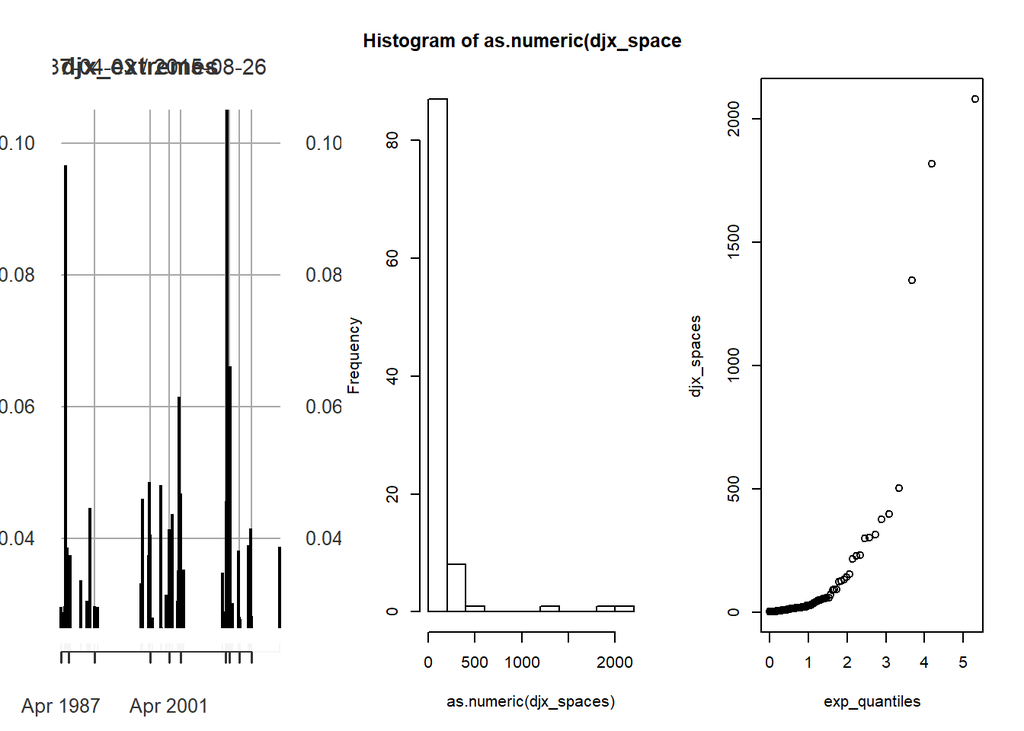

```r
# Partition plotting area into 3 pieces
par(mfrow = c(1, 3))

# Plot djx_extremes
plot(djx_extremes, type="h")

# Compute the spaces between the times of the extremes
djx_spaces <- diff(time(djx_extremes))

# Make a histogram of these spaces
hist(as.numeric(djx_spaces))

# Make a Q-Q plot of djx_spaces against exp_quantiles
qqplot(exp_quantiles, djx_spaces)
```

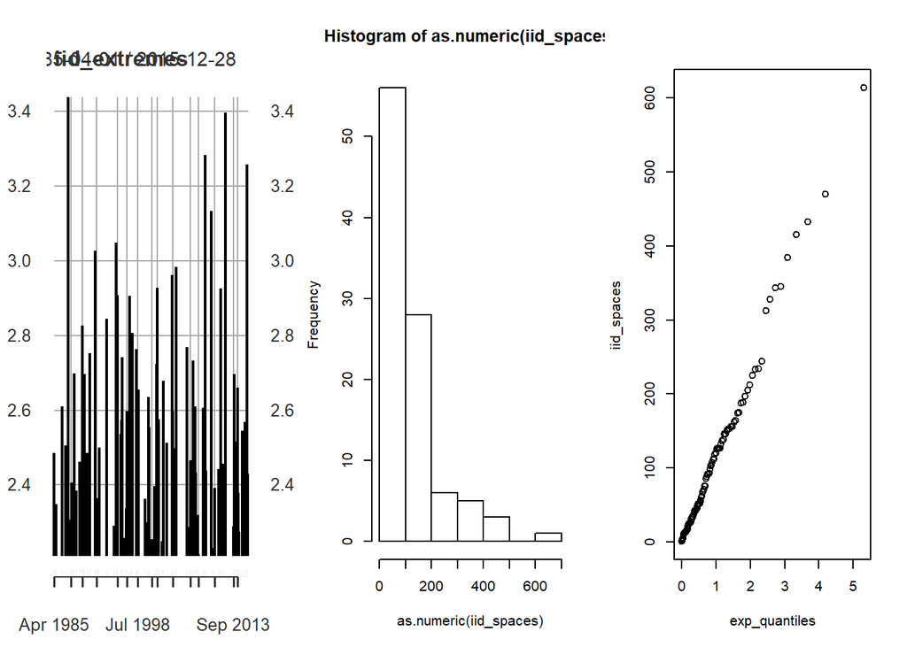

```r
# Carry out the previous 4 steps for iid_extremes
plot(iid_extremes, type="h")
iid_spaces <- diff(time(iid_extremes))
hist(as.numeric(iid_spaces))
qqplot(exp_quantiles, iid_spaces)
```

```r
par(mfrow = c(1, 1))


# When the function acf() is applied to a multivariate time series, we obtain a matrix of plots with the usual sample acf plots on the diagonal, and plots of the correlations between different series at different lags off the diagonal.

data(FTSE, package='qrmdata')
data(SMI, package='qrmdata')

dj_i <- diff(log(DJ))['2005/2015']
ftse_i <- diff(log(FTSE))['2005/2015']
smi_i <- diff(log(SMI))['2005/2015']

indexes <- merge(dj_i, ftse_i, smi_i, all = FALSE)
str(indexes)
```

```
## An 'xts' object on 2005-01-03/2015-12-30 containing:
##   Data: num [1:2723, 1:3] -0.00498 -0.00924 -0.0031 0.00236 -0.00178 ...
##  - attr(*, "dimnames")=List of 2
##   ..$ : NULL
##   ..$ : chr [1:3] "X.DJI" "X.FTSE" "X.SSMI"
##   Indexed by objects of class: [Date] TZ: UTC
##   xts Attributes:
## List of 2
##  $ src    : chr "yahoo"
##  $ updated: POSIXct[1:1], format: "2016-01-02 20:42:12"
```

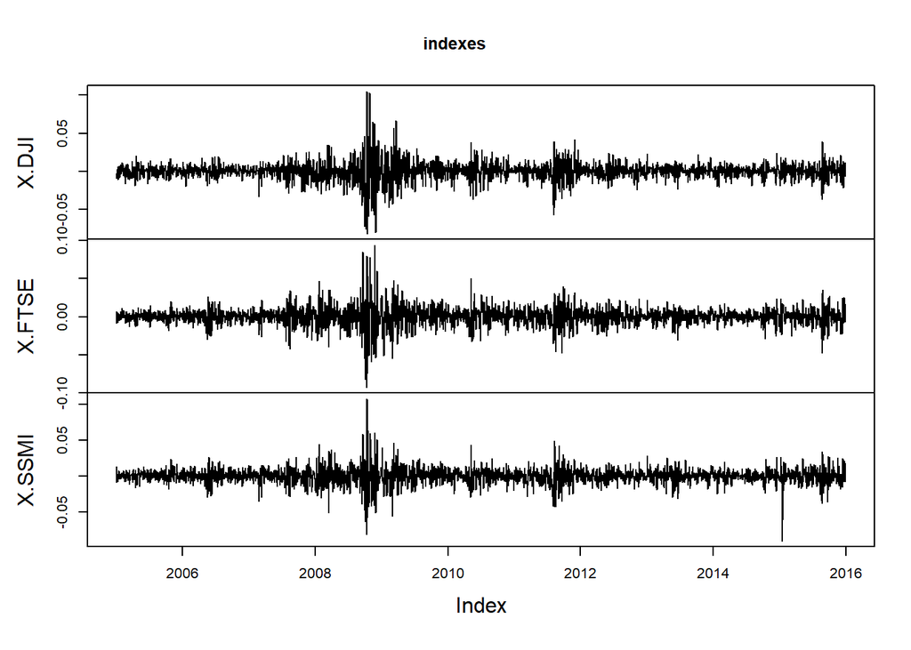

```r
# Make a time series plot of indexes with plot.zoo and a pairwise scatterplot with pairs
plot.zoo(indexes)
```

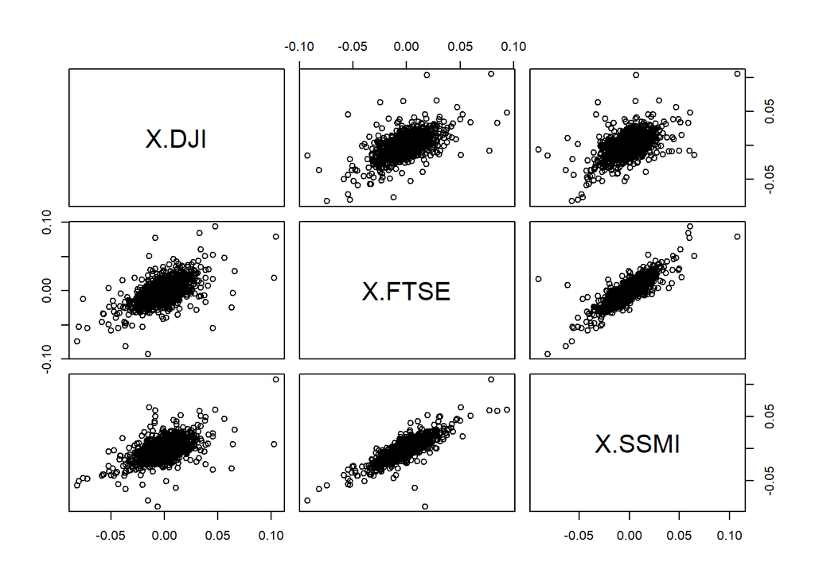

```r
pairs(as.zoo(indexes))
```

```r
# Calculate the sample correlation matrix of indexes
cor(indexes)
```

```
##            X.DJI    X.FTSE    X.SSMI
## X.DJI  1.0000000 0.5903534 0.5408565
## X.FTSE 0.5903534 1.0000000 0.8226086
## X.SSMI 0.5408565 0.8226086 1.0000000
```

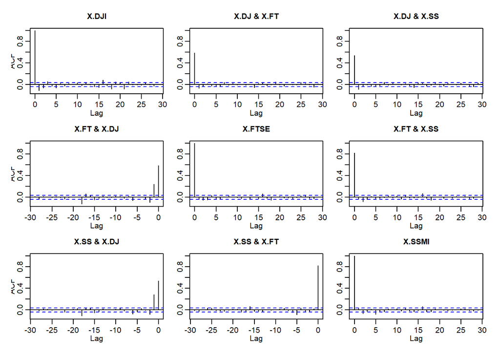

```r
# Plot the sample acfs and cross-correlation functions for the returns in indexes
acf(indexes)
```

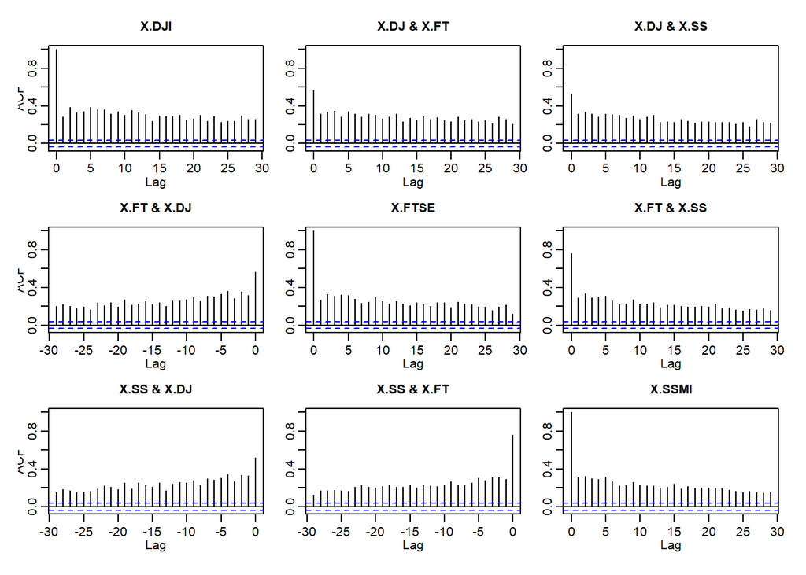

```r
# Plots the sample acfs and cross-correlations functions for the absolute values of indexes
acf(abs(indexes))
```

```r
data(CHF_USD, package="qrmdata")
fx <- diff(log(merge(GBP_USD, EUR_USD, USD_JPY, CHF_USD, all = TRUE)))['2011/2015']
str(fx)
```

```
## An 'xts' object on 2011-01-01/2015-12-31 containing:
##   Data: num [1:1826, 1:4] 0.007007 -0.000128 -0.005976 0.001867 0.000386 ...
##  - attr(*, "dimnames")=List of 2
##   ..$ : NULL
##   ..$ : chr [1:4] "GBP.USD" "EUR.USD" "JPY.USD" "CHF.USD"
##   Indexed by objects of class: [Date] TZ: UTC
##   xts Attributes:
## List of 2
##  $ src    : chr "oanda"
##  $ updated: POSIXct[1:1], format: "2016-01-02 20:55:00"
```

```r
fx_w <- apply.weekly(fx, FUN=colSums)
str(fx_w)
```

```
## An 'xts' object on 2011-01-02/2015-12-31 containing:
##   Data: num [1:262, 1:4] 0.00688 -0.00417 0.02069 0.0081 -0.0091 ...
##  - attr(*, "dimnames")=List of 2
##   ..$ : NULL
##   ..$ : chr [1:4] "GBP.USD" "EUR.USD" "JPY.USD" "CHF.USD"
##   Indexed by objects of class: [POSIXct,POSIXt] TZ: UTC
##   xts Attributes:
## List of 2
##  $ src    : chr "oanda"
##  $ updated: POSIXct[1:1], format: "2016-01-02 20:55:00"
```

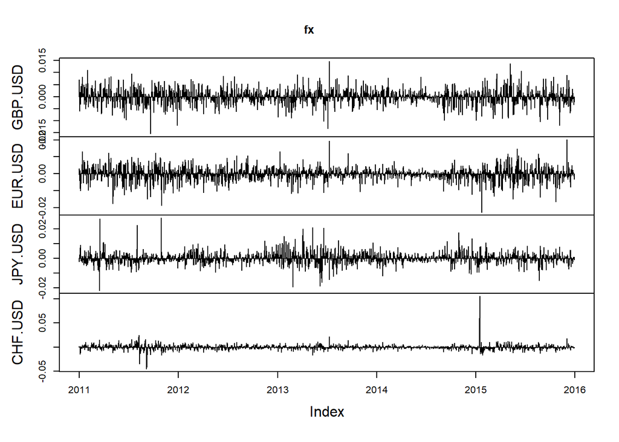

```r
# Plot fx and fx_w
plot.zoo(fx, type="h")
```

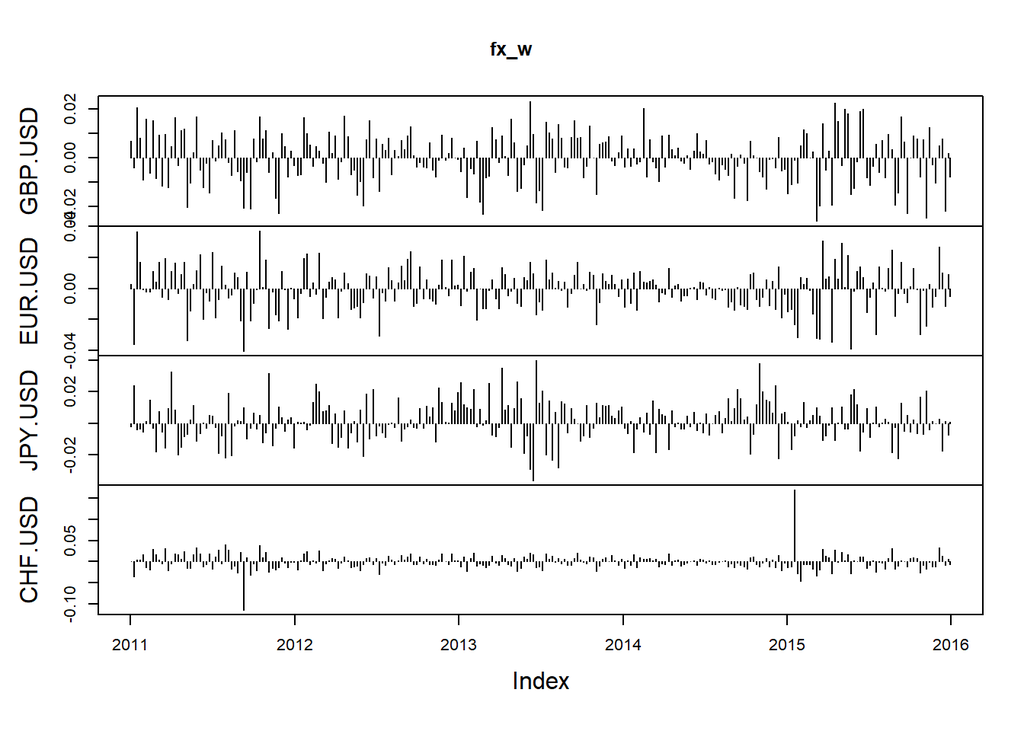

```r
plot.zoo(fx_w, type="h")
```

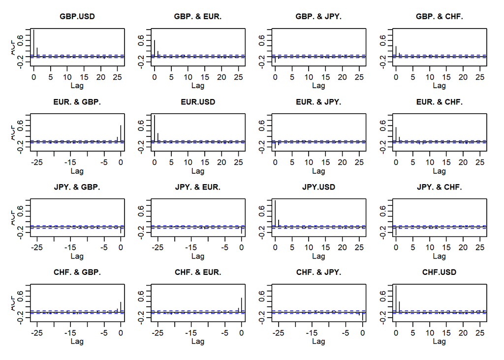

```r
# Make acf plots of fx and the absolute values of fx
acf(fx)
```

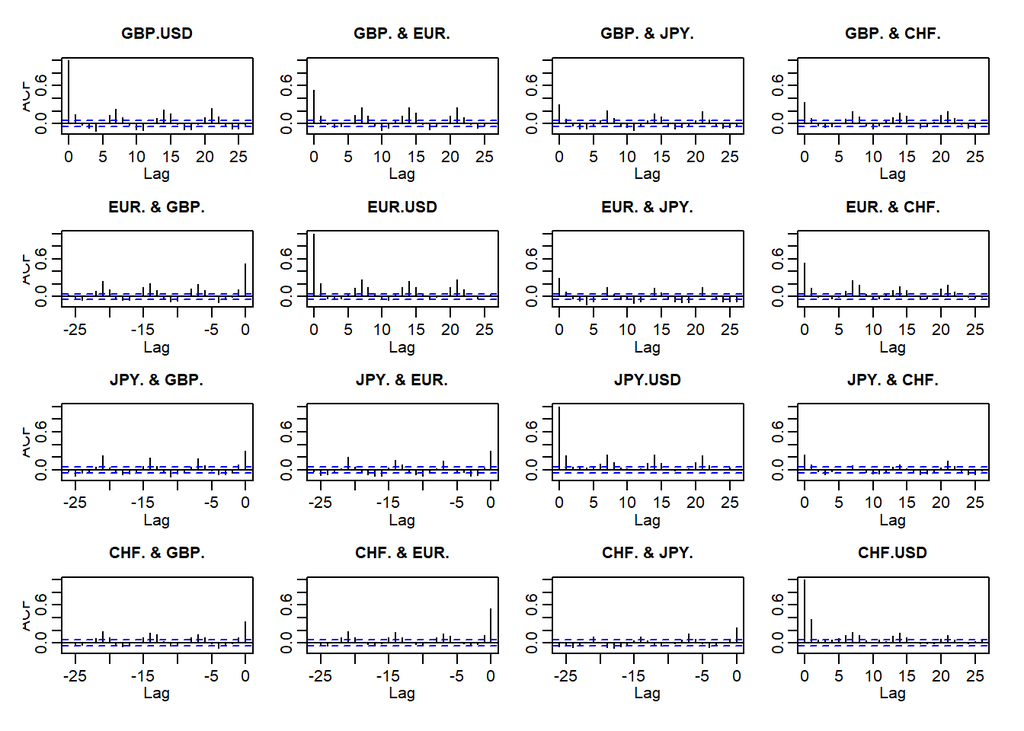

```r
acf(abs(fx))
```

```r
# Apply the Ljung-Box test to the components of fx and their absolute values
apply(fx, 2, Box.test, lag = 10, type = "Ljung")
```

```
## $GBP.USD
##
##  Box-Ljung test
##
## data:  newX[, i]
## X-squared = 206.44, df = 10, p-value < 2.2e-16
##
##
## $EUR.USD
##
##  Box-Ljung test
##
## data:  newX[, i]
## X-squared = 195.33, df = 10, p-value < 2.2e-16
##
##
## $JPY.USD
##
##  Box-Ljung test
##
## data:  newX[, i]
## X-squared = 141.56, df = 10, p-value < 2.2e-16
##
##
## $CHF.USD
##
##  Box-Ljung test
##
## data:  newX[, i]
## X-squared = 310.46, df = 10, p-value < 2.2e-16
```

```r
apply(abs(fx), 2, Box.test, lag = 10, type = "Ljung")
```

```
## $GBP.USD
##
##  Box-Ljung test
##
## data:  newX[, i]
## X-squared = 235.89, df = 10, p-value < 2.2e-16
##
##
## $EUR.USD
##
##  Box-Ljung test
##
## data:  newX[, i]
## X-squared = 307.05, df = 10, p-value < 2.2e-16
##
##
## $JPY.USD
##
##  Box-Ljung test
##
## data:  newX[, i]
## X-squared = 264.54, df = 10, p-value < 2.2e-16
##
##
## $CHF.USD
##
##  Box-Ljung test
##
## data:  newX[, i]
## X-squared = 376.51, df = 10, p-value < 2.2e-16
```

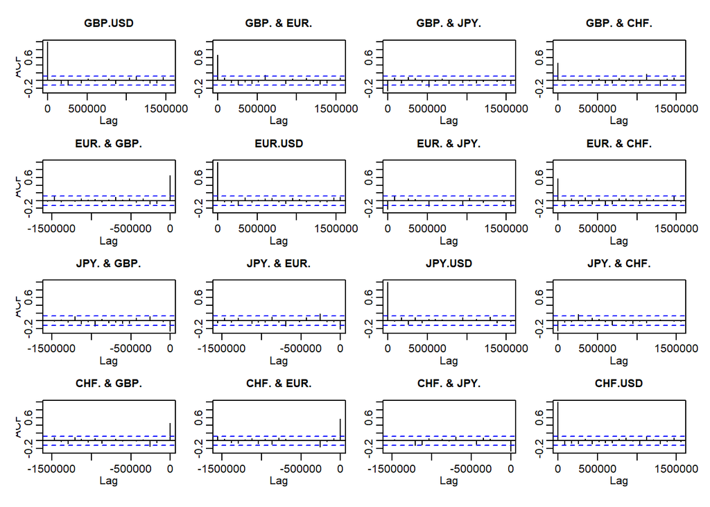

```r
# Make acf plots of fx_w and the absolute values of fx_w
acf(fx_w)
```

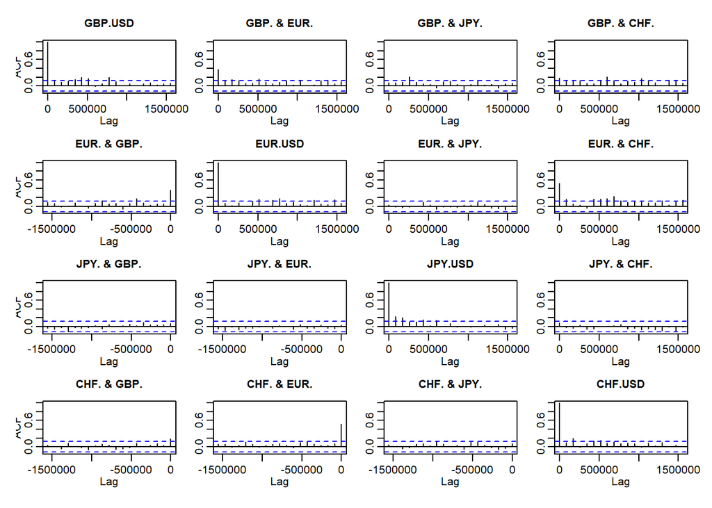

```r
acf(abs(fx_w))
```

```r
# Apply the Ljung-Box test to the components of fx_w and their absolute values
apply(fx_w, 2, Box.test, lag = 10, type = "Ljung")
```

```
## $GBP.USD
##
##  Box-Ljung test
##
## data:  newX[, i]
## X-squared = 8.8896, df = 10, p-value = 0.5426
##
##
## $EUR.USD
##
##  Box-Ljung test
##
## data:  newX[, i]
## X-squared = 10.364, df = 10, p-value = 0.4091
##
##
## $JPY.USD
##
##  Box-Ljung test
##
## data:  newX[, i]
## X-squared = 7.7924, df = 10, p-value = 0.6491
##
##
## $CHF.USD
##
##  Box-Ljung test
##
## data:  newX[, i]
## X-squared = 10.961, df = 10, p-value = 0.3605
```

```r
apply(abs(fx_w), 2, Box.test, lag = 10, type = "Ljung")
```

```
## $GBP.USD
##
##  Box-Ljung test
##
## data:  newX[, i]
## X-squared = 47.097, df = 10, p-value = 9.066e-07
##
##
## $EUR.USD
##
##  Box-Ljung test
##
## data:  newX[, i]
## X-squared = 29.168, df = 10, p-value = 0.00117
##
##
## $JPY.USD
##
##  Box-Ljung test
##
## data:  newX[, i]
## X-squared = 46.153, df = 10, p-value = 1.345e-06
##
##
## $CHF.USD
##
##  Box-Ljung test
##
## data:  newX[, i]
## X-squared = 34.449, df = 10, p-value = 0.000155
```

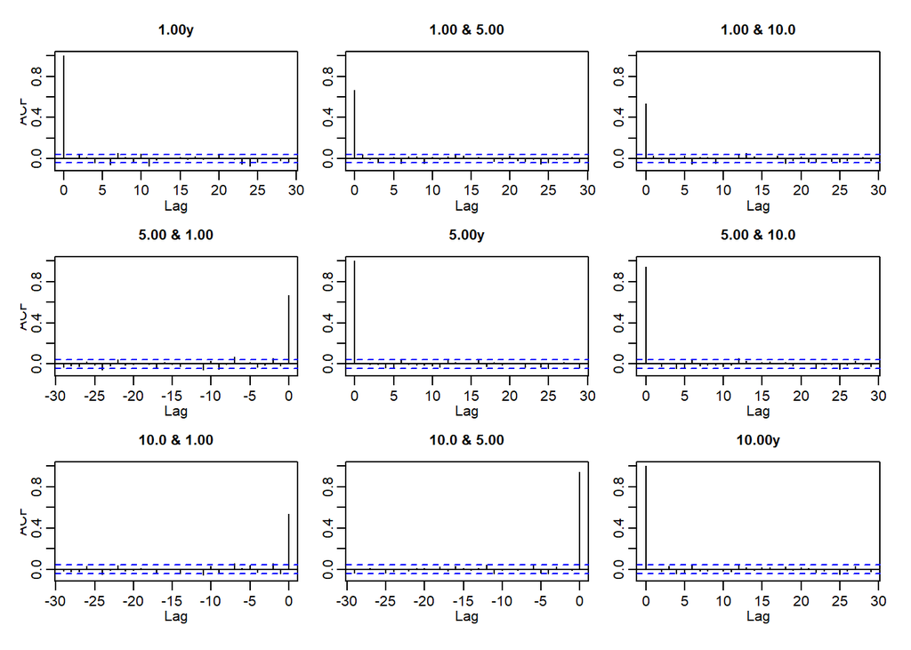

```r
# Make acf plots of zcb_x and the absolute values of zcb_x
acf(zcb_x[-1, c("1.00y", "5.00y", "10.00y")])
```

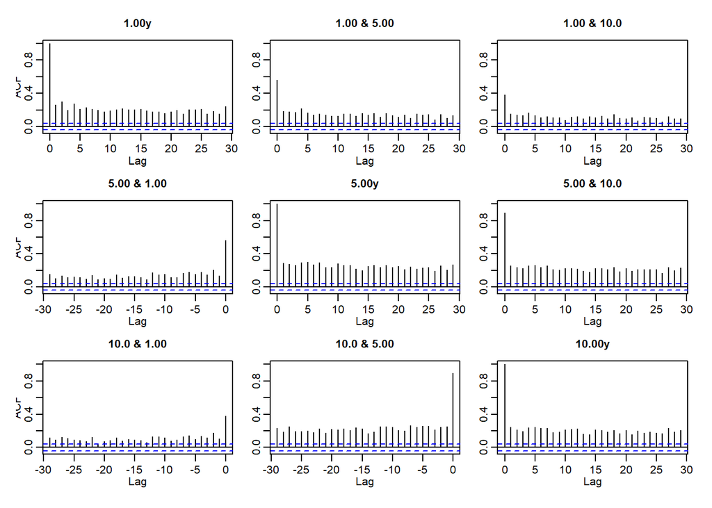

```r
acf(abs(zcb_x[-1, c("1.00y", "5.00y", "10.00y")]))
```

```r
# Apply the Ljung-Box test to the components of zcb_x and their absolute values
apply(zcb_x[-1, c("1.00y", "5.00y", "10.00y")], 2, FUN=Box.test, lag=10, type="Ljung")
```

```
## $`1.00y`
##
##  Box-Ljung test
##
## data:  newX[, i]
## X-squared = 34.528, df = 10, p-value = 0.0001503
##
##
## $`5.00y`
##
##  Box-Ljung test
##
## data:  newX[, i]
## X-squared = 11.875, df = 10, p-value = 0.2935
##
##
## $`10.00y`
##
##  Box-Ljung test
##
## data:  newX[, i]
## X-squared = 17.072, df = 10, p-value = 0.07279
```

```r
apply(abs(zcb_x[-1, c("1.00y", "5.00y", "10.00y")]), 2, FUN=Box.test, lag=10, type="Ljung")
```

```
## $`1.00y`
##
##  Box-Ljung test
##
## data:  newX[, i]
## X-squared = 1246.9, df = 10, p-value < 2.2e-16
##
##
## $`5.00y`
##
##  Box-Ljung test
##
## data:  newX[, i]
## X-squared = 1826.1, df = 10, p-value < 2.2e-16
##
##
## $`10.00y`
##
##  Box-Ljung test
##
## data:  newX[, i]
## X-squared = 1147.4, df = 10, p-value < 2.2e-16
```

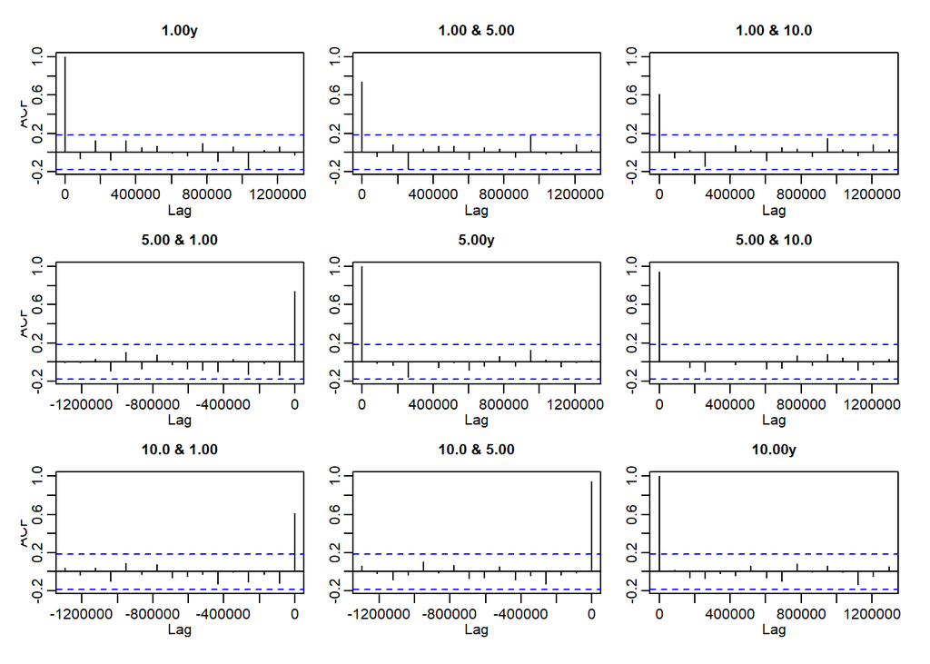

```r
# Make acf plots of zcbx_m and the absolute values of zcbx_m
acf(zcbx_m)
```

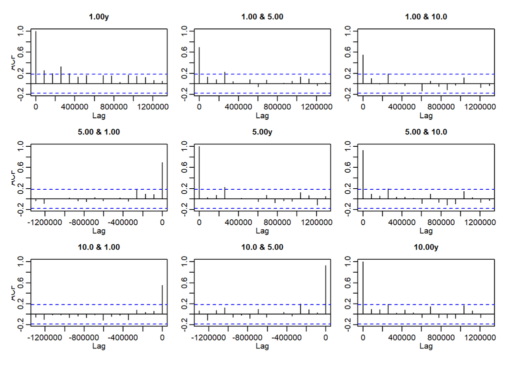

```r
acf(abs(zcbx_m))
```

```r
# Apply the Ljung-Box test to the components of zcbx_m and their absolute values
apply(zcbx_m, 2, FUN=Box.test, lag=10, type="Ljung")
```

```
## $`1.00y`
##
##  Box-Ljung test
##
## data:  newX[, i]
## X-squared = 8.3951, df = 10, p-value = 0.5903
##
##
## $`5.00y`
##
##  Box-Ljung test
##
## data:  newX[, i]
## X-squared = 5.4826, df = 10, p-value = 0.8567
##
##
## $`10.00y`
##
##  Box-Ljung test
##
## data:  newX[, i]
## X-squared = 4.2486, df = 10, p-value = 0.9354
```

```r
apply(abs(zcbx_m), 2, FUN=Box.test, lag=10, type="Ljung")
```

```
## $`1.00y`
##
##  Box-Ljung test
##
## data:  newX[, i]
## X-squared = 41.992, df = 10, p-value = 7.524e-06
##
##
## $`5.00y`
##
##  Box-Ljung test
##
## data:  newX[, i]
## X-squared = 8.9816, df = 10, p-value = 0.5338
##
##
## $`10.00y`
##
##  Box-Ljung test
##
## data:  newX[, i]
## X-squared = 11.917, df = 10, p-value = 0.2906
```

Chapter 4 - Estimating Portfolio value-at-risk (VaR)

Value-at-risk and expected shortfall:

- Consider the distribution of losses over a fixed time period (such as two weeks) with no rebalancing
  - The risk measure is just a statistic for the loss distribution - common to take a quantile (99.5% or 99% or 95%) for the tails
  - The alpha-VaR is the alpha-quantile for the loss distribution (alpha is also known as the confidence level)
  - The loss distribution is estimated based on historical data
- Expected shortfall (ES) is becoming increasingly important in banking
  - Tail VaR (TVaR), conditional VaR (cVaR), or expected shortfall (ES)
  - alpha-ES is the expected loss given that the loss exceeds alpha-VaR

International equity portfolio:

- Example of UK investor with 30% FTSE, 40% S&P 500, 30% SMI (Swiss)
  - 5 risk factors - FTSE, S&P 500, SMI, GBP/USD, GBP/CHF
  - Can look at each of the individualized risk factors first, using the log-returns method
- Historical simulation allows for estimating data - non-parametric approach involving resampling of past data
  - Resample historical risk-factor returns and examine their impact on the current portfolio
  - Loss operator shows effect of different risk-factor returns on the portfolio - for the specific portfolio and at the specific point in time
  - VaR and ES can then be estimated based on the sample quantiles of the resampled data

Option portfolio and Black-Scholes:

- European options have a strike price K at a future time T - call is the right to buy at price K, put is the right to sell at price K
  - Price depends on current price S, interest rate r, time to maturity T-t, and annualized volatility sigma
  - Black-Scholes was designed to price options assuming normal distributions over returns
  - Option is said to be “in the money” if it would be exercised at its current price
- Estimating volatility for options pricing models is challenging - typically, an “implied volatility” is assumed
  - The quoted option prices suggest how the market is pricing volatility at the current point in time
  - The VIX index from the CBOE is one of the measures of applied volatility for options traded on the S&P 500
  - The implied volatility is itself a very volatile measurement

Historical simulation for the option example:

- When an option is valued using Black-Scholes, changes in any of S, sigma, or r will change the price of the underlying option
  - For this example, assume that r remains constant and that a single day has passed

Wrap up:

- Enhnacements include serial dependence for risk calculations (improve VaR and ES through volatility clustering) - filtered historical simulation with GARCH or EWMA
- Improvements are available for both calculating VaR and ES - small sample sizes are especially risky, and can be improved using parametric-tailed methods (extreme value theory)

Example code includes:

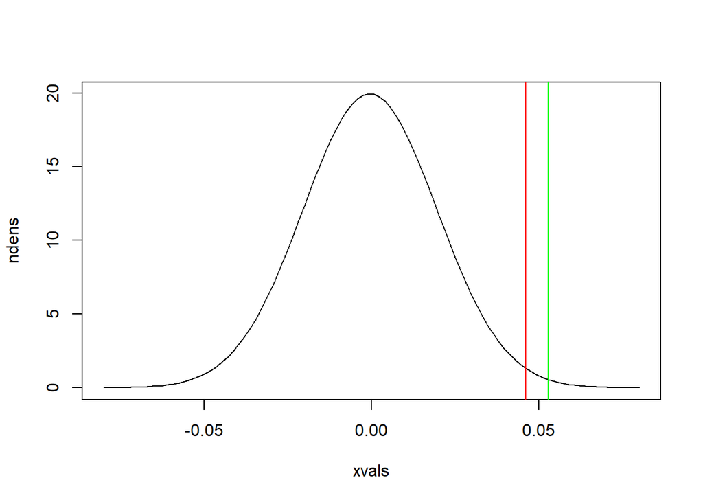

```r
# The standard function qnorm() calculates quantiles of a normal distribution from the probability p, the mean, and standard deviation, and thus can be used to calculate value-at-risk (VaR)
# The function ESnorm() from the QRM package calculates the expected shortfall (ES) for a normal distribution from the probability p, location parameter mu, and scale parameter sd:
# qnorm(p, mean = 0, sd = 1)
# ESnorm(p, mu = 0, sd = 1)

par(mfrow=c(1, 1))
par(mfcol=c(1, 1))

mu <- mean(diff(log(DJ))['2008/2009'])
sigma <- sd(diff(log(DJ))['2008/2009'])

# Make a sequence of 100 x-values going from -4*sigma to 4*sigma
xvals <- seq(from = -4*sigma, to = 4*sigma, length.out = 100)

# Compute the density of a N(mu, sigma^2) distribution at xvals
ndens <- dnorm(xvals, mean = mu, sd = sigma)

# Plot ndens against xvals
plot(xvals, ndens, type="l")

# Compute the 99% VaR and 99% ES of a N(mu, sigma^2) distribution
VaR99 <- qnorm(0.99, mean=mu, sd=sigma)
ES99 <- QRM::ESnorm(0.99, mu=mu, sd=sigma)

# Draw vertical lines at VaR99 and ES99 in red and green
abline(v = VaR99, col = "red")
abline(v = ES99, col = "green")
```

```r
data(SP500, package="qrmdata")
data(CHF_GBP, package="qrmdata")
data(USD_GBP, package="qrmdata")
ftse_r <- FTSE['2000/2012']
smi_r <- SMI['2000/2012']
sp500_r <- SP500['2000/2012']
usdgbp_r <- USD_GBP['2000/2012']
chfgbp_r <- CHF_GBP['2000/2012']
riskfactors <- merge(ftse_r, sp500_r, smi_r, usdgbp_r, chfgbp_r, all=FALSE)
str(riskfactors)
```

```
## An 'xts' object on 2000-01-04/2012-12-31 containing:
##   Data: num [1:3210, 1:5] 6666 6536 6447 6505 6608 ...
##  - attr(*, "dimnames")=List of 2
##   ..$ : NULL
##   ..$ : chr [1:5] "X.FTSE" "X.GSPC" "X.SSMI" "USD.GBP" ...
##   Indexed by objects of class: [Date] TZ: UTC
##   xts Attributes:
## List of 2
##  $ src    : chr "yahoo"
##  $ updated: POSIXct[1:1], format: "2016-01-02 20:42:15"
```

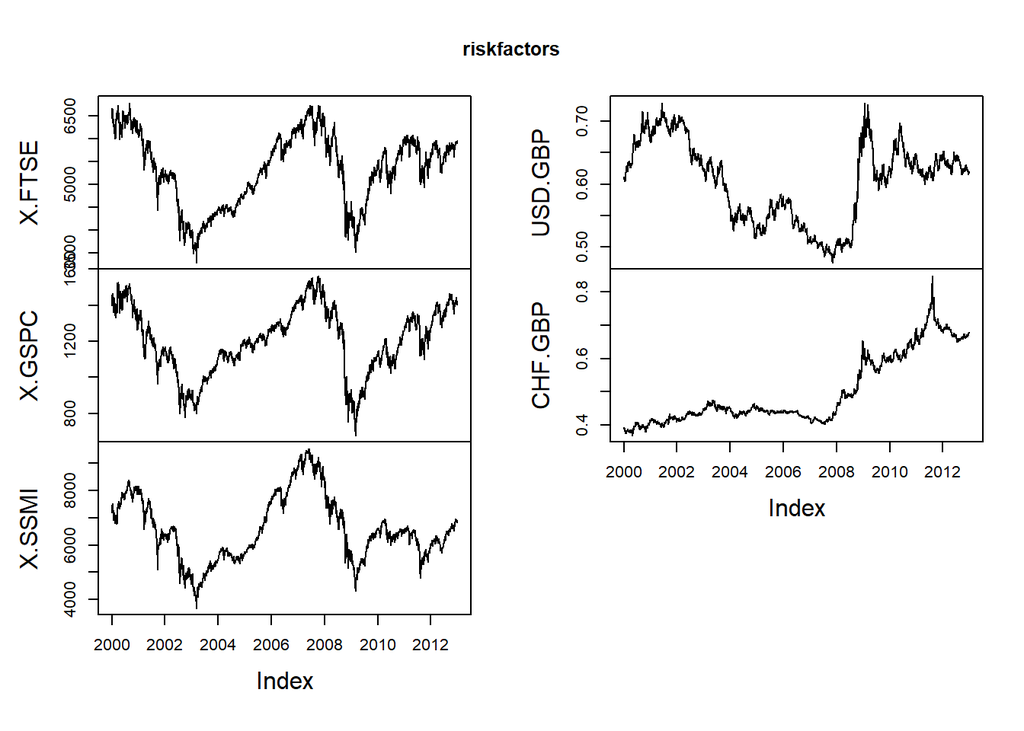

```r
# Plot the risk-factor data
plot.zoo(riskfactors)
```

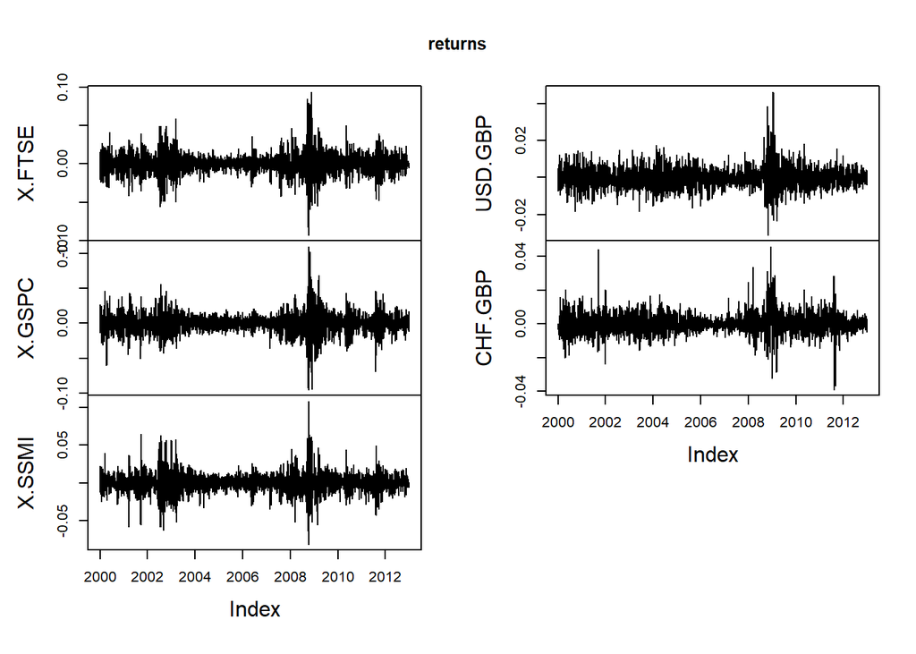

```r
# Calculate the log-returns, assign to returns, and plot
returns <- diff(log(riskfactors))[-1, ]
plot.zoo(returns)
```